# An Introduction to Statistical Learning (2013)

Solutions to Exercises

by Brian Hassett

# Chapter 7 Conceptual Exercises

This notebook outlines solutions to the conceptual exercises in Chapter 7 of **An Introduction to Statistical Learning** (James et al. (2013)[^1]).

## Exercise 1

*It was mentioned in the chapter that a cubic regression spline with one knot at $\xi$ can be obtained using a basis of the form $x$, $x_2$, $x_3$, $(x − \xi)_{+}^{3}$, where $(x − \xi)_{+}^{3} = (x − \xi)^3$ if $x > \xi$ and equals $0$ otherwise.*

*We will now show that a function of the form*

$$f(x)=\beta_{0}+\beta_{1} x+\beta_{2} x^{2}+\beta_{3} x^{3}+\beta_{4}(x-\xi)_{+}^{3}$$
*is indeed a cubic regression spline, regardless of the values of $\beta_{0},~ \beta_{1},~ \beta_{2},~ \beta_{3},~ \beta_{4}$.*

1. *Find a cubic polynomial*
   $$f_{1}(x) = a_{1}+b_{1} x+c_{1} x^{2}+d_{1} x^{3}$$
   *such that $f(x) = f_{1}(x)$ for all $x \le \xi$. Express $a_1$, $b_1$, $c_1$, $d_1$ in terms of $\beta_{0}$, $\beta_{1}$, $\beta_{2}$, $\beta_{3}$, $\beta_{4}$.*
2. *Find a cubic polynomial*
   $$f_{2}(x) = a_{2} + b_{2}x + c_{2}x^{2} + d_{2}x^{3}$$
   *such that $f(x) = f_{2}(x)$ for all $x > \xi$. Express $a_2$, $b_2$, $c_2$, $d_2$ in terms of $\beta_{0}$, $\beta_{1}$, $\beta_{2}$, $\beta_{3}$, $\beta_{4}$. We have now established that $f(x)$ is a piecewise polynomial.*
3. *Show that $f_1(\xi) = f_2(\xi)$. That is, $f(x)$ is continuous at $\xi$.*
4. *Show that $f_1'(\xi) = f_2'(\xi)$. That is, $f'(x)$ is continuous at $\xi$*.
5. *Show that $f_1''(\xi) = f_2''(\xi)$. That is, $f''(x)$ is continuous at $\xi$*.

*Therefore, $f(x)$ is indeed a cubic spline.*

**Preliminaries:**

Rewrite $f(x)$ with the expanded version of the truncated power basis function:
$$f(x)=\beta_{0}+\beta_{1} x+\beta_{2} x^{2}+\beta_{3} x^{3} + \beta_{4}\times \begin{cases} 0 & x \le \xi \\ (x-\xi)^{3} & x > \xi \end{cases}$$

### (a)

$$f_{1}(x)=\beta_{0} + \beta_{1}x + \beta_{2}x^{2} + \beta_{3}x^{3} + \beta_{4}(0)$$
$$a_{1} = \beta_{0},~~ b_{1} = \beta_{1},~~ c_{1} = \beta_{2},~~ d_{1} = \beta_{3}$$

### (b)

$$f_{2}(x)=\beta_{0} + \beta_{1}x + \beta_{2}x^{2} + \beta_{3}x^{3} + \beta_{4}(x-\xi)^{3}$$

$$f_{2}(x)=\beta_{0} + \beta_{1}x + \beta_{2}x^{2} + \beta_{3}x^{3} + \beta_{4}(x^3 - \xi^3 -3x^2\xi +3x\xi^2)$$

$$f_{2}(x) = \beta_{0} + \beta_{1}x + \beta_{2}x^{2} + \beta_{3}x^{3} + \beta_{4}x^3 - \beta_{4}\xi^3 - 3\beta_{4}x^2\xi + 3\beta_{4}x\xi^2$$

$$f_{2}(x) = (\beta_{0} - \beta_{4}\xi^3) + (\beta_{1} + 3\beta_{4}\xi^2)x + (\beta_{2} - 3\beta_{4}\xi)x^{2} + (\beta_{3} + \beta_{4})x^{3}$$

$$a_{2} = (\beta_{0} - \beta_{4}\xi^3),~~ b_{2} = (\beta_{1} + 3\beta_{4}\xi^2),~~ c_{2} = (\beta_{2} - 3\beta_{4}\xi),~~ d_{2} = (\beta_{3} + \beta_{4})$$

### (c)

If $f_{1}(\xi) = f_{2}(\xi)$, then
$$\beta_{0} + \beta_{1}(\xi) + \beta_{2}(\xi^{2}) + \beta_{3}(\xi^{3}) = (\beta_{0} - \beta_{4}\xi^3) + (\beta_{1} + 3\beta_{4}\xi^2)(\xi) + (\beta_{2} - 3\beta_{4}\xi)(\xi^{2}) + (\beta_{3} + \beta_{4})(\xi^{3})$$

$$\beta_{0} + \beta_{1}\xi + \beta_{2}\xi^{2} + \beta_{3}\xi^{3} = \beta_{0} - \beta_{4}\xi^3 + \beta_{1}\xi + 3\beta_{4}\xi^3 + \beta_{2}\xi^{2} - 3\beta_{4}\xi^3 + \beta_{3}\xi^{3} + \beta_{4}\xi^{3}$$

$$\beta_{0} + \beta_{1}\xi + \beta_{2}\xi^{2} + \beta_{3}\xi^{3} = \beta_{0} + \beta_{1}\xi + \beta_{2}\xi^{2} + \beta_{3}\xi^{3} + \beta_{4}(-\xi^3 + 3\xi^3 - 3\xi^3 + \xi^{3})$$

$$\beta_{0} + \beta_{1}\xi + \beta_{2}\xi^{2} + \beta_{3}\xi^{3} = \beta_{0} + \beta_{1}\xi + \beta_{2}\xi^{2} + \beta_{3}\xi^{3} + \beta_{4}(0)$$

$$\beta_{0} + \beta_{1}\xi + \beta_{2}\xi^{2} + \beta_{3}\xi^{3} = \beta_{0} + \beta_{1}\xi + \beta_{2}\xi^{2} + \beta_{3}\xi^{3} ~\square$$

### (d)

Calculate the first derivatives:

$$f_{1}'(x) = \beta_{1} + 2\beta_{2}x + 3\beta_{3}x^2$$
$$f_{2}'(x) = (\beta_1 + 3\beta_4 \xi^2) + 2(\beta_2 - 3\beta_4 \xi)x + 3(\beta_3 + \beta_4)x^2$$

If $f_{1}'(\xi) = f_{2}'(\xi)$, then
$$(\beta_{1}) + 2(\beta_{2})(\xi) + 3(\beta_{3})(\xi^{2}) = (\beta_{1} + 3\beta_{4}\xi^2) + 2(\beta_{2} - 3\beta_{4}\xi)(\xi) + 3(\beta_{3} + \beta_{4})(\xi^{2})$$

$$\beta_{1} + 2\beta_{2}\xi + 3\beta_{3}\xi^{2} = \beta_{1} + 3\beta_{4}\xi^2 + 2\beta_{2}\xi - 6\beta_{4}\xi^2 + 3\beta_{3}\xi^{2} + 3\beta_{4}\xi^{2}$$

$$\beta_{1} + 2\beta_{2}\xi + 3\beta_{3}\xi^{2} = \beta_{1} + 2\beta_{2}\xi + 3\beta_{3}\xi^{2} + (3\beta_{4}\xi^2 - 6\beta_{4}\xi^2 + 3\beta_{4}\xi^2)$$

$$\beta_{1} + 2\beta_{2}\xi + 3\beta_{3}\xi^{2} = \beta_{1} + 2\beta_{2}\xi + 3\beta_{3}\xi^{2} + (0)$$

$$\beta_{1} + 2\beta_{2}\xi + 3\beta_{3}\xi^{2} = \beta_{1} + 2\beta_{2}\xi + 3\beta_{3}\xi^{2} ~\square$$

### (e)

Calculate the second derivatives:

$$f_{1}''(x) = 2\beta_{2} + 6\beta_{3}x$$
$$f_{2}''(x) = 2(\beta_2 - 3\beta_4 \xi) + 6(\beta_3 + \beta_4)x$$

If $f_{1}''(\xi) = f_{2}''(\xi)$, then
$$2(\beta_{2}) + 6(\beta_{3})(\xi) = 2(\beta_{2} - 3\beta_{4}\xi) + 6(\beta_{3} + \beta_{4})(\xi)$$

$$2\beta_{2} + 6\beta_{3}\xi = 2\beta_{2} - 6\beta_{4}\xi + 6\beta_{3}\xi + 6\beta_{4}\xi$$

$$2\beta_{2} + 6\beta_{3}\xi = 2\beta_{2} + 6\beta_{3}\xi + (-6\beta_{4}\xi + 6\beta_{4}\xi)$$

$$2\beta_{2} + 6\beta_{3}\xi = 2\beta_{2} + 6\beta_{3}\xi + (0)$$

$$2\beta_{2} + 6\beta_{3}\xi = 2\beta_{2} + 6\beta_{3}\xi ~\square$$

## Exercise 2

*Suppose that a curve $\hat{g}$ is computed to smoothly fit a set of $n$ points using the following formula:*
$$\hat{g}=\arg \min _{g}\left(\sum_{i=1}^{n}\left(y_{i}-g\left(x_{i}\right)\right)^{2}+\lambda \int\left[g^{(m)}(x)\right]^{2} d x\right),$$

*where $g^{(m)}$ represents the $m$th derivative of $g$ (and $g^{(0)}=g$). Provide example sketches of ĝ in each of the following scenarios.*

1. $\lambda = \infty$, $m = 0$.
2. $\lambda = \infty$, $m = 1$.
3. $\lambda = \infty$, $m = 2$.
4. $\lambda = \infty$, $m = 3$.
5. $\lambda = 0$, $m = 3$.

**Preliminaries:**

For ease of reference, we will break the quantity that is being minimized to find $\hat{g}$ into two terms:

1. The RSS term: $\sum_{i=1}^{n}\left(y_{i}-g\left(x_{i}\right)\right)^{2}$
2. The penalty term: $\lambda \int\left[g^{(m)}(x)\right]^{2} dx$

Create some non-linear (quadratic) sample data with one predictor `x`:

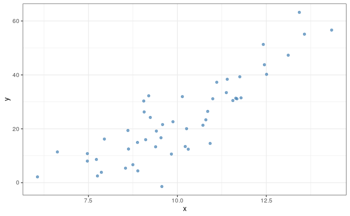

```r
set.seed(123)
n <- 50
x <- rnorm(n, mean = 10, sd = 2)
eps <- rnorm(n, sd = 8)
y <- 0.6*x^2 - 5*x + 10 + eps
p1 <- ggplot(data.frame(x, y)) +
  geom_point(aes(x, y), color = "steelblue", alpha = 0.7)
p1
```

### (a)

$\lambda = \infty, m = 0$:

When $\lambda = \infty$, the penalty term is forced to zero. Since $m = 0$, this means that the penalty term is minimized when $g^{(0)} = g = 0$. This means that the curve $\hat{g}$ is also zero. This gives $\hat{g}$ as a straight line along the x-axis.

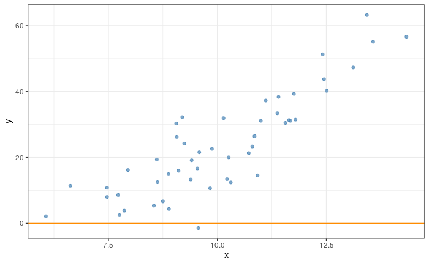

### (b)

$\lambda = \infty, m = 1$:

When $\lambda = \infty$, the penalty term is forced to zero. Since $m = 1$, this means that the penalty term is minimized when $g^{(1)} = 0$. Since the first derivative of any constant is zero, this means that the function $g$ is some constant, $c$. If we choose $\bar{y}$ as the constant, i.e. the mean value of $y$, then we also minimize the RSS term.

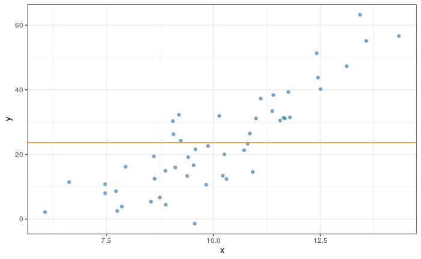

### (c)

$\lambda = \infty, m = 2$:

When $\lambda = \infty$, the penalty term is forced to zero. Since $m = 2$, that means that that the penalty term is minimized when $g^{(2)} = 0$. Since the second derivative of any straight line is zero, this means that the function $g$ can be any straight line $bx + c$. Then $\hat{g}$ is a straight line with slope $b$ and intercept $c$. If we choose $b = \hat{\beta_0}$ and $c = \hat{\beta_1}$, i.e. the linear least squares coefficients, then we also minimize the RSS term.

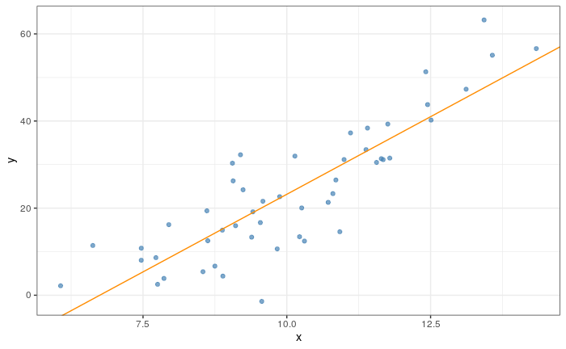

### (d)

$\lambda = \infty, m = 3$

When $\lambda = \infty$, the penalty term is forced to zero. Since $m = 3$, that means that that the penalty term is minimized when $g^{(3)} = 0$. Since the third derivative of any quadratic is zero, this means that the function $g$ can be any quadratic given by $ax^2 + bx + c$. Then $\hat{g}$ is a quadratic given by $ax^2 + bx + c$. If we choose $\hat{g}$ as the quadratic least squares curve, then we also minimize the RSS term.

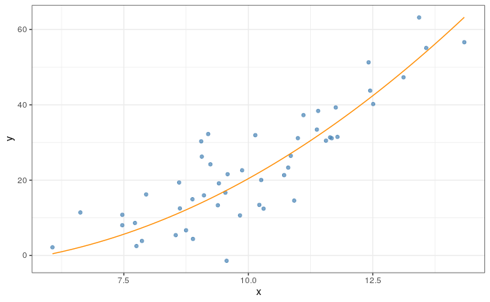

### (e)

$\lambda = 0, m = 3$

When $\lambda = 0$, the penalty term no longer plays a role. Therefore, to minimize the expression we minimize the RSS term. The RSS is minimized to zero when the curve $\hat{g}$ passes through all points in the data.

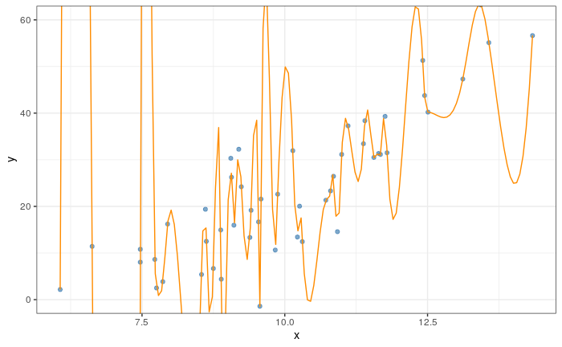

## Exercise 3

*Suppose we fit a curve with basis functions $b_1(X) = X$, $b_2(X) = (X − 1)^2 I(X \ge 1)$. (Note that $I(X \ge 1)$ equals $1$ for $X \ge 1$ and $0$ otherwise.) We fit the linear regression model*
$$Y = \beta_0 + \beta_1b_1(X) + \beta_2b_2(X) + \epsilon,$$

*and obtain coefficient estimates $\hat{\beta_0} = 1$, $\hat{\beta_1} = 1$, $\hat{\beta_2} = -2$. Sketch the estimated curve between $X = −2$ and $X = 2$. Note the intercept, slopes, and other relevant information.*

Create a function from the details given:

```r
beta0 <- 1
beta1 <- 1
beta2 <- -2

f <- function(x) beta0 + beta1*x + (beta2*(x - 1)^2 )*(x >= 1)
```

Find the intercepts and slope (of the linear region):

```r
# x-intercept (y = 0):
# 0 = beta0 + beta1*x + (beta2*(x - 1)^2 )*(x >= 1)
# beta1*x + (beta2*(x - 1)^2 )*(x >= 1) = -beta0
# beta1*x + (beta2*(x^2 - 2*x + 1))*(x >= 1) = -beta0
# beta1*x + (beta2*x^2 - 2*beta2*x + beta2)*(x >= 1) = -beta0
# beta1*x + (beta2*x^2 - 2*beta2*x + beta2)*(0) = -beta0 # we want the negative
# x = -beta0/beta1
x_int <- -beta0 / beta1

# y-intercept (x = 0):
y_int <- f(0)

# Slope:
m <- (f(0) - f(-2)) / (0 - (-2))

c(x_int, y_int, m)
```

```
[1] -1  1  1
```

The $x$-intercept is $-1$; the $y$-intercept is $1$; the slope of the linear region is $1$.

Plot the function from $X = -2$ to $X = 2$:

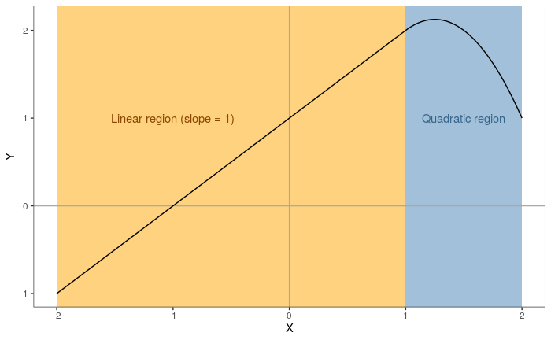

## Exercise 4

*Suppose we fit a curve with basis functions $b_1(X) = I(0 \le X \le 2) - (X − 1)I(1 \le X \le 2)$, $b_2(X) = (X − 3)I(3 \le X \le 4) + I(4 < X \le 5)$. We fit the linear regression model*
$$Y = \beta_0 + \beta_1b_1(X) + \beta_2b_2(X) + \epsilon,$$
*and obtain coefficient estimates $\hat{\beta_0} = 1$, $\hat{\beta_1} = 1$, $\hat{\beta_2} = 3$. Sketch the estimated curve between $X = −2$ and $X = 2$. Note the intercepts, slopes, and other relevant information.*

Produce a function from the details given:

```r
beta0 <- 1
beta1 <- 1
beta2 <- 3

f <- function(x) {
  beta0 +
  beta1*((0 <= x && x <= 2) - (x - 1)*(1 <=x && x <= 2)) +
  beta2*((x - 3)*(3 <= x && x <= 4) + (4 < x && x <=5))
}
```

Find the $y$-intercept and slopes:

```r
# y-intercept (x = 0):
y_int <- f(0)

# Slope:
m1 <- 0 # slope of horizontal segments
m2 <- (f(2) - f(1)) / (2 - 1) # sloped segment

c(y_int, m1, m2)
```

```
[1]  2  0 -1
```

The $y$-intercept is $2$. The constant segments have slope of $0$, the non-constant segment has slope of $-1$.

Plot the function from $X = -2$ to $X = 2$:

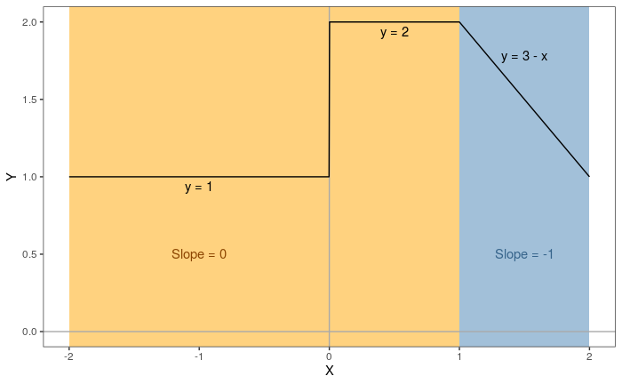

## Exercise 5

*Consider the two curves, $\hat{g_1}$ and $\hat{g_2}$, defined by*
$$\hat{g}_{1}=\arg \min _{g}\left(\sum_{i=1}^{n}\left(y_{i}-g\left(x_{i}\right)\right)^{2}+\lambda \int\left[g^{(3)}(x)\right]^{2} d x\right)$$

$$\hat{g}_{2}=\arg \min _{g}\left(\sum_{i=1}^{n}\left(y_{i}-g\left(x_{i}\right)\right)^{2}+\lambda \int\left[g^{(4)}(x)\right]^{2} d x\right)$$

*where $g^{(m)}$ represents the $m$th derivative of $g$.*

1. *As $\lambda \rightarrow \infty$, will $\hat{g}_{1}$ or $\hat{g}_{2}$ have the smaller training RSS?*
2. *As $\lambda \rightarrow \infty$, will $\hat{g}_{1}$ or $\hat{g}_{2}$ have the smaller test RSS?*
3. *For $\lambda = 0$, will $\hat{g}_{1}$ or $\hat{g}_{2}$ have the smaller training and test RSS?*

### (a)

$\hat{g}_{1}$ is minimized when the third derivative of $g$ is zero. Since the third derivative of any quadratic is zero, $\hat{g}_{1}$ is minimized when $g$ is a quadratic function of $x$.

$\hat{g}_{2}$ is minimized when the fourth derivative of $g$ is zero. Since the fourth derivative of any cubic polynomial is zero, $\hat{g}_{2}$ is minimized when $g$ is a cubic polynomial function of $x$.

Since the degree of polynomial is higher for $\hat{g}_{2}$, it can provide a more flexible fit to the training data. Therefore it will likely have a smaller training RSS than $\hat{g}_{1}$.

### (b)

Since $\hat{g}_{2}$ provides a more flexible fit to the training data, it is more prone to overfitting. Therefore $\hat{g}_{1}$ *may* have a smaller test RSS than $\hat{g}_{2}$. It would depend on the true relationship between $X$ and $Y$ which we don’t know in this case.

### (c)

Since $\lambda = 0$, the penalty term is zero in both cases. Therefore $\hat{g}_{1}$ and $\hat{g}_{2}$ will have the same training and test RSS. Additionally, in the training case the RSS will be zero since both curves will interpolate all the data points perfectly.

[^1]: James G, Witten D, Hastie T, Tibshirani R (2013). *An Introduction to Statistical Learning: with Applications in R*. Springer, 1st edition.